# Bikeshare Space-Time Prediction

# CREATE TEMPORAL LAG VARIABLES

```r
# Sort by station and time
study_panel <- study_panel %>%
  arrange(start_station, interval60)

# Create lag variables WITHIN each station
study_panel <- study_panel %>%
  group_by(start_station) %>%
  mutate(
    lag1Hour = lag(Trip_Count, 1),
    lag2Hours = lag(Trip_Count, 2),
    lag3Hours = lag(Trip_Count, 3),
    lag12Hours = lag(Trip_Count, 12),
    lag1day = lag(Trip_Count, 24)
  ) %>%
  ungroup()

# Remove rows with NA lags (first 24 hours for each station)
study_panel_complete <- study_panel %>%
  filter(!is.na(lag1day))

cat("Rows after removing NA lags:", format(nrow(study_panel_complete), big.mark = ","), "\n")
```

```
Rows after removing NA lags: 708,785
```

## Visualize Lag Correlations

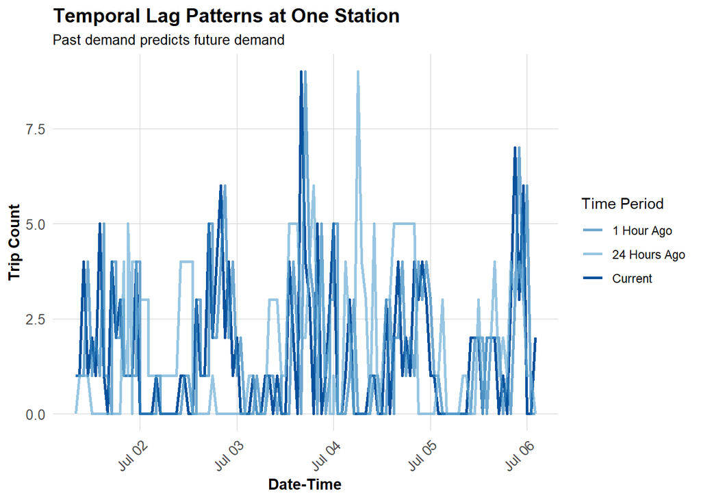

```r
# Sample one station to visualize
example_station <- study_panel_complete %>%
  filter(start_station == first(start_station)) %>%
  head(168)  # One week

# Plot actual vs lagged demand
ggplot(example_station, aes(x = interval60)) +
  geom_line(aes(y = Trip_Count, color = "Current"), linewidth = 1) +
  geom_line(aes(y = lag1Hour, color = "1 Hour Ago"), linewidth = 1, alpha = 0.7) +
  geom_line(aes(y = lag1day, color = "24 Hours Ago"), linewidth = 1, alpha = 0.7) +
  scale_color_manual(values = c(
    "Current" = "#08519c",
    "1 Hour Ago" = "#3182bd",
    "24 Hours Ago" = "#6baed6"
  )) +
  labs(
    title = "Temporal Lag Patterns at One Station",
    subtitle = "Past demand predicts future demand",
    x = "Date-Time",
    y = "Trip Count",
    color = "Time Period"
  ) +
  plotTheme
```

# TEMPORAL TRAIN/TEST SPLIT

```r
# Split by week
# Q3 has weeks 27-40 (July-Spet)
# Train on weeks 27-35
# Test on weeks 36-40

# Which stations have trips in BOTH early and late periods?
early_stations <- study_panel_complete %>%
  filter(week < 36) %>%
  filter(Trip_Count > 0) %>%
  distinct(start_station) %>%
  pull(start_station)

late_stations <- study_panel_complete %>%
  filter(week >= 36) %>%
  filter(Trip_Count > 0) %>%
  distinct(start_station) %>%
  pull(start_station)

# Keep only stations that appear in BOTH periods
common_stations <- intersect(early_stations, late_stations)


# Filter panel to only common stations
study_panel_complete <- study_panel_complete %>%
  filter(start_station %in% common_stations)

# NOW create train/test split
train <- study_panel_complete %>%
  filter(week < 36)

test <- study_panel_complete %>%
  filter(week >= 36)

cat("Training observations:", format(nrow(train), big.mark = ","), "\n")
```

```
Training observations: 501,541
```

#BUILD PREDICTIVE MODELS

## Model 1: Baseline (Time + Weather)

```r
# Create day of week factor with treatment (dummy) coding
train <- train %>%
  mutate(dotw_simple = factor(dotw, levels = c("Mon", "Tue", "Wed", "Thu", "Fri", "Sat", "Sun")))

# Set contrasts to treatment coding (dummy variables)
contrasts(train$dotw_simple) <- contr.treatment(7)

# Now run the model
model1 <- lm(
  Trip_Count ~ as.factor(hour) + dotw_simple + Temperature + Precipitation,
  data = train
)

summary(model1)
```

```
Call:
lm(formula = Trip_Count ~ as.factor(hour) + dotw_simple + Temperature +
    Precipitation, data = train)

Residuals:
    Min      1Q  Median      3Q     Max
-1.7125 -0.7561 -0.2121  0.2110 21.1067

Coefficients:
                    Estimate Std. Error t value             Pr(>|t|)
(Intercept)        0.4115692  0.0261453  15.742 < 0.0000000000000002 ***
as.factor(hour)1  -0.0540262  0.0117895  -4.583    0.000004593990039 ***
as.factor(hour)2  -0.1261545  0.0119723 -10.537 < 0.0000000000000002 ***
as.factor(hour)3  -0.1774976  0.0119619 -14.839 < 0.0000000000000002 ***
as.factor(hour)4  -0.1673862  0.0118130 -14.170 < 0.0000000000000002 ***
as.factor(hour)5  -0.0559641  0.0121381  -4.611    0.000004015439965 ***
as.factor(hour)6   0.1840261  0.0118983  15.467 < 0.0000000000000002 ***
as.factor(hour)7   0.4500867  0.0118841  37.873 < 0.0000000000000002 ***
as.factor(hour)8   0.9366676  0.0118247  79.213 < 0.0000000000000002 ***
as.factor(hour)9   0.6136735  0.0119565  51.326 < 0.0000000000000002 ***
as.factor(hour)10  0.4823405  0.0118642  40.655 < 0.0000000000000002 ***
as.factor(hour)11  0.5258989  0.0114750  45.830 < 0.0000000000000002 ***
as.factor(hour)12  0.6141261  0.0116979  52.499 < 0.0000000000000002 ***
as.factor(hour)13  0.6775067  0.0118321  57.260 < 0.0000000000000002 ***
as.factor(hour)14  0.7451786  0.0116539  63.942 < 0.0000000000000002 ***
as.factor(hour)15  0.8546126  0.0116993  73.048 < 0.0000000000000002 ***
as.factor(hour)16  1.0712931  0.0119723  89.481 < 0.0000000000000002 ***
as.factor(hour)17  1.4012597  0.0120098 116.676 < 0.0000000000000002 ***
as.factor(hour)18  1.0581635  0.0120162  88.061 < 0.0000000000000002 ***
as.factor(hour)19  0.8235956  0.0120580  68.303 < 0.0000000000000002 ***
as.factor(hour)20  0.5860658  0.0119470  49.055 < 0.0000000000000002 ***
as.factor(hour)21  0.4237912  0.0117910  35.942 < 0.0000000000000002 ***
as.factor(hour)22  0.2860782  0.0116010  24.660 < 0.0000000000000002 ***
as.factor(hour)23  0.1313521  0.0116223  11.302 < 0.0000000000000002 ***
dotw_simple2       0.0465693  0.0064074   7.268    0.000000000000365 ***
dotw_simple3       0.0263717  0.0064389   4.096    0.000042094602228 ***
dotw_simple4       0.0422632  0.0064500   6.552    0.000000000056646 ***
dotw_simple5       0.0876232  0.0067093  13.060 < 0.0000000000000002 ***
dotw_simple6       0.0063724  0.0068308   0.933                0.351
dotw_simple7      -0.0651120  0.0066560  -9.782 < 0.0000000000000002 ***
Temperature       -0.0026108  0.0003125  -8.355 < 0.0000000000000002 ***
Precipitation     -0.4063579  0.0264563 -15.360 < 0.0000000000000002 ***
---
Signif. codes:  0 '***' 0.001 '**' 0.01 '*' 0.05 '.' 0.1 ' ' 1

Residual standard error: 1.229 on 501509 degrees of freedom
Multiple R-squared:  0.1062,    Adjusted R-squared:  0.1062
F-statistic:  1923 on 31 and 501509 DF,  p-value: < 0.00000000000000022
```

## Model 2: Add Temporal Lags

```r
model2 <- lm(
  Trip_Count ~ as.factor(hour) + dotw_simple + Temperature + Precipitation +
    lag1Hour + lag3Hours + lag1day,
  data = train
)

summary(model2)
```

```
Call:
lm(formula = Trip_Count ~ as.factor(hour) + dotw_simple + Temperature +
    Precipitation + lag1Hour + lag3Hours + lag1day, data = train)

Residuals:
    Min      1Q  Median      3Q     Max
-8.1305 -0.4719 -0.1282  0.1603 17.3967

Coefficients:
                    Estimate Std. Error t value             Pr(>|t|)
(Intercept)        0.1932603  0.0222592   8.682 < 0.0000000000000002 ***
as.factor(hour)1  -0.0107791  0.0100346  -1.074             0.282737
as.factor(hour)2  -0.0230237  0.0101934  -2.259             0.023902 *
as.factor(hour)3  -0.0418173  0.0101883  -4.104         0.0000405372 ***
as.factor(hour)4  -0.0135448  0.0100669  -1.345             0.178474
as.factor(hour)5   0.0853365  0.0103467   8.248 < 0.0000000000000002 ***
as.factor(hour)6   0.2572424  0.0101459  25.354 < 0.0000000000000002 ***
as.factor(hour)7   0.3976395  0.0101391  39.219 < 0.0000000000000002 ***
as.factor(hour)8   0.6977846  0.0101001  69.087 < 0.0000000000000002 ***
as.factor(hour)9   0.2417010  0.0102189  23.652 < 0.0000000000000002 ***
as.factor(hour)10  0.1866410  0.0101214  18.440 < 0.0000000000000002 ***
as.factor(hour)11  0.2709541  0.0097863  27.687 < 0.0000000000000002 ***
as.factor(hour)12  0.3363633  0.0099792  33.706 < 0.0000000000000002 ***
as.factor(hour)13  0.3735371  0.0100963  36.997 < 0.0000000000000002 ***
as.factor(hour)14  0.4308988  0.0099455  43.326 < 0.0000000000000002 ***
as.factor(hour)15  0.5046635  0.0099906  50.514 < 0.0000000000000002 ***
as.factor(hour)16  0.6477453  0.0102364  63.279 < 0.0000000000000002 ***
as.factor(hour)17  0.8735161  0.0102958  84.842 < 0.0000000000000002 ***
as.factor(hour)18  0.4671195  0.0103277  45.230 < 0.0000000000000002 ***
as.factor(hour)19  0.3485184  0.0103319  33.732 < 0.0000000000000002 ***
as.factor(hour)20  0.1725713  0.0102382  16.856 < 0.0000000000000002 ***
as.factor(hour)21  0.1582020  0.0100713  15.708 < 0.0000000000000002 ***
as.factor(hour)22  0.1177674  0.0098897  11.908 < 0.0000000000000002 ***
as.factor(hour)23  0.0555991  0.0098945   5.619         0.0000000192 ***
dotw_simple2       0.0187953  0.0054539   3.446             0.000569 ***
dotw_simple3       0.0001545  0.0054807   0.028             0.977511
dotw_simple4       0.0125519  0.0054908   2.286             0.022255 *
dotw_simple5       0.0210761  0.0057149   3.688             0.000226 ***
dotw_simple6      -0.0264412  0.0058176  -4.545         0.0000054930 ***
dotw_simple7      -0.0480896  0.0056659  -8.488 < 0.0000000000000002 ***
Temperature       -0.0029854  0.0002660 -11.222 < 0.0000000000000002 ***
Precipitation     -0.0757371  0.0225517  -3.358             0.000784 ***
lag1Hour           0.4045613  0.0013124 308.268 < 0.0000000000000002 ***
lag3Hours          0.1268892  0.0012904  98.337 < 0.0000000000000002 ***
lag1day            0.1383590  0.0011966 115.623 < 0.0000000000000002 ***
---
Signif. codes:  0 '***' 0.001 '**' 0.01 '*' 0.05 '.' 0.1 ' ' 1

Residual standard error: 1.046 on 501506 degrees of freedom
Multiple R-squared:  0.3526,    Adjusted R-squared:  0.3525
F-statistic:  8032 on 34 and 501506 DF,  p-value: < 0.00000000000000022
```

## Model 3: Add Demographics

```r
train <- train %>%
  mutate(
    Med_Inc = coalesce(Med_Inc.x, Med_Inc.y),
    Percent_Taking_Transit = coalesce(Percent_Taking_Transit.x, Percent_Taking_Transit.y),
    Percent_White = coalesce(Percent_White.x, Percent_White.y)
  )

model3 <- lm(
  Trip_Count ~ as.factor(hour) + dotw_simple + Temperature + Precipitation +
    lag1Hour + lag3Hours + lag1day +
    Med_Inc + Percent_Taking_Transit + Percent_White,
  data = train
)

summary(model3)
```

```
Call:
lm(formula = Trip_Count ~ as.factor(hour) + dotw_simple + Temperature +
    Precipitation + lag1Hour + lag3Hours + lag1day + Med_Inc +
    Percent_Taking_Transit + Percent_White, data = train)

Residuals:
    Min      1Q  Median      3Q     Max
-7.9347 -0.4856 -0.1343  0.2060 17.2849

Coefficients:
                             Estimate     Std. Error t value
(Intercept)             0.07035865497  0.02296933347   3.063
as.factor(hour)1       -0.01263550808  0.00999293248  -1.264
as.factor(hour)2       -0.02776401437  0.01015121714  -2.735
as.factor(hour)3       -0.04817183994  0.01014641982  -4.748
as.factor(hour)4       -0.02048830240  0.01002564380  -2.044
as.factor(hour)5        0.07908923666  0.01030411404   7.676
as.factor(hour)6        0.25339228067  0.01010388679  25.079
as.factor(hour)7        0.39875573855  0.01009690120  39.493
as.factor(hour)8        0.70588394474  0.01005881343  70.176
as.factor(hour)9        0.25598622952  0.01017877653  25.149
as.factor(hour)10       0.20073214358  0.01008168255  19.911
as.factor(hour)11       0.28384981282  0.00974762163  29.120
as.factor(hour)12       0.34945565388  0.00993976595  35.157
as.factor(hour)13       0.38692281122  0.01005643789  38.475
as.factor(hour)14       0.44397248351  0.00990618549  44.818
as.factor(hour)15       0.51898813825  0.00995148772  52.152
as.factor(hour)16       0.66562512447  0.01019751703  65.273
as.factor(hour)17       0.89487190310  0.01025829554  87.234
as.factor(hour)18       0.48980934212  0.01029071438  47.597
as.factor(hour)19       0.36801774723  0.01029335492  35.753
as.factor(hour)20       0.19178844146  0.01019993206  18.803
as.factor(hour)21       0.17034684079  0.01003111238  16.982
as.factor(hour)22       0.12549360840  0.00984930693  12.741
as.factor(hour)23       0.05907603346  0.00985352962   5.995
dotw_simple2            0.02023183401  0.00543127992   3.725
dotw_simple3            0.00165536737  0.00545793226   0.303
dotw_simple4            0.01433619693  0.00546800575   2.622
dotw_simple5            0.02496157892  0.00569143075   4.386
dotw_simple6           -0.02384996084  0.00579349646  -4.117
```

[output cut: 39 more lines]

```
dotw_simple7           < 0.0000000000000002 ***
Temperature            < 0.0000000000000002 ***
Precipitation            0.0000523354751391 ***
lag1Hour               < 0.0000000000000002 ***
lag3Hours              < 0.0000000000000002 ***
lag1day                < 0.0000000000000002 ***
Med_Inc                < 0.0000000000000002 ***
Percent_Taking_Transit < 0.0000000000000002 ***
Percent_White          < 0.0000000000000002 ***
---
Signif. codes:  0 '***' 0.001 '**' 0.01 '*' 0.05 '.' 0.1 ' ' 1

Residual standard error: 1.042 on 501503 degrees of freedom
Multiple R-squared:  0.3579,    Adjusted R-squared:  0.3579
F-statistic:  7557 on 37 and 501503 DF,  p-value: < 0.00000000000000022
```

## Model 4: Add Station Fixed Effects

```r
model4 <- lm(
  Trip_Count ~ as.factor(hour) + dotw_simple + Temperature + Precipitation +
    lag1Hour + lag3Hours + lag1day +
    Med_Inc + Percent_Taking_Transit + Percent_White +
    as.factor(start_station),
  data = train
)

# Summary too long with all station dummies, just show key metrics
cat("Model 4 R-squared:", summary(model4)$r.squared, "\n")
```

```
Model 4 R-squared: 0.3835545
```

```r
cat("Model 4 Adj R-squared:", summary(model4)$adj.r.squared, "\n")
```

```
Model 4 Adj R-squared: 0.3831905
```

## Model 5: Add Rush Hour Interaction

```r
model5 <- lm(
  Trip_Count ~ as.factor(hour) + dotw_simple + Temperature + Precipitation +
    lag1Hour + lag3Hours + lag1day + rush_hour + as.factor(month) +
    Med_Inc + Percent_Taking_Transit + Percent_White +
    as.factor(start_station) +
    rush_hour * weekend,  # Rush hour effects different on weekends
  data = train
)

cat("Model 5 R-squared:", summary(model5)$r.squared, "\n")
```

```
Model 5 R-squared: 0.3868177
```

```r
cat("Model 5 Adj R-squared:", summary(model5)$adj.r.squared, "\n")
```

```
Model 5 Adj R-squared: 0.386452
```

# MODEL EVALUATION

## Calculate Predictions and MAE

```r
# Get predictions on test set

# Create day of week factor with treatment (dummy) coding
test <- test %>%
  mutate(dotw_simple = factor(dotw, levels = c("Mon", "Tue", "Wed", "Thu", "Fri", "Sat", "Sun")))

test <- test %>%
  mutate(
    Med_Inc = coalesce(Med_Inc.x, Med_Inc.y),
    Percent_Taking_Transit = coalesce(Percent_Taking_Transit.x, Percent_Taking_Transit.y),
    Percent_White = coalesce(Percent_White.x, Percent_White.y)
  )
# Set contrasts to treatment coding (dummy variables)
contrasts(test$dotw_simple) <- contr.treatment(7)

test <- test %>%
  mutate(
    pred1 = predict(model1, newdata = test),
    pred2 = predict(model2, newdata = test),
    pred3 = predict(model3, newdata = test),
    pred4 = predict(model4, newdata = test),
    pred5 = predict(model5, newdata = test)
  )

# Calculate MAE for each model
mae_results <- data.frame(
  Model = c(
    "1. Time + Weather",
    "2. + Temporal Lags",
    "3. + Demographics",
    "4. + Station FE",
    "5. + Rush Hour Interaction"
  ),
  MAE = c(
    mean(abs(test$Trip_Count - test$pred1), na.rm = TRUE),
    mean(abs(test$Trip_Count - test$pred2), na.rm = TRUE),
    mean(abs(test$Trip_Count - test$pred3), na.rm = TRUE),
    mean(abs(test$Trip_Count - test$pred4), na.rm = TRUE),
    mean(abs(test$Trip_Count - test$pred5), na.rm = TRUE)
  )
)

kable(mae_results,
      digits = 2,
      caption = "Mean Absolute Error by Model (Test Set)",
      col.names = c("Model", "MAE (trips)")) %>%
  kable_styling(bootstrap_options = c("striped", "hover"))
```

Mean Absolute Error by Model (Test Set)

| Model | MAE (trips) |
| --- | --- |
| 1. Time + Weather | 0.84 |
| 2. + Temporal Lags | 0.71 |
| 3. + Demographics | 0.71 |
| 4. + Station FE | 0.71 |
| 5. + Rush Hour Interaction | 0.71 |

## Visualize Model Comparison

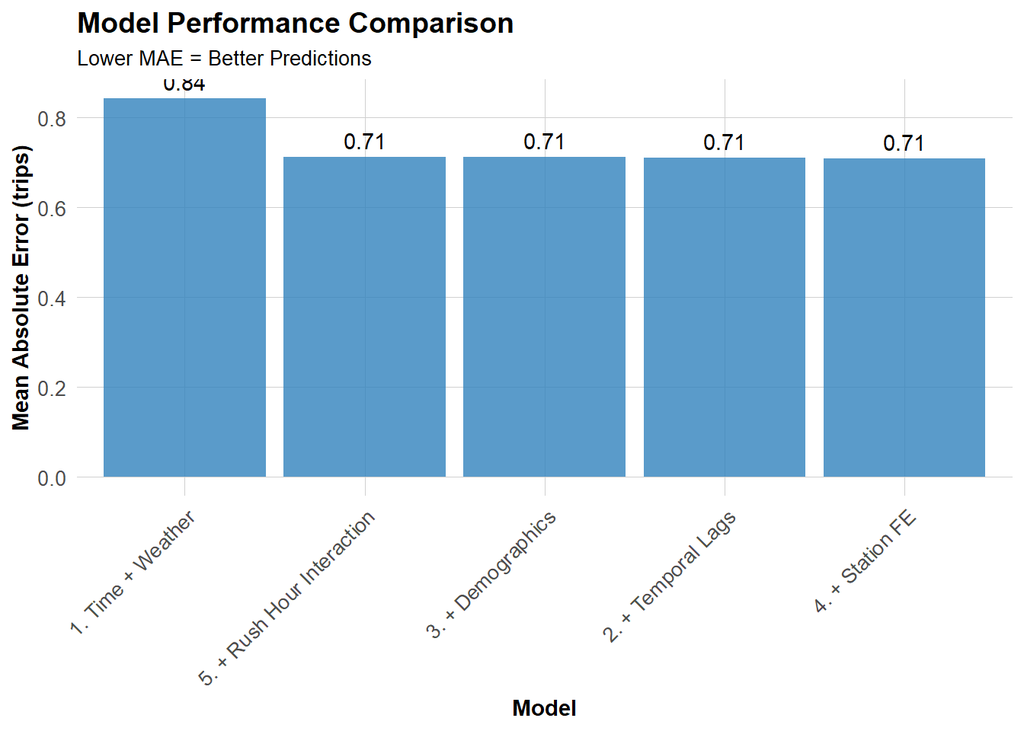

```r
ggplot(mae_results, aes(x = reorder(Model, -MAE), y = MAE)) +
  geom_col(fill = "#3182bd", alpha = 0.8) +
  geom_text(aes(label = round(MAE, 2)), vjust = -0.5) +
  labs(
    title = "Model Performance Comparison",
    subtitle = "Lower MAE = Better Predictions",
    x = "Model",
    y = "Mean Absolute Error (trips)"
  ) +
  plotTheme +
  theme(axis.text.x = element_text(angle = 45, hjust = 1))
```

# Compare Results to Q1 2025

## MAE Comparison

```r
## MAE comparison
q1_mae <- c(0.60, 0.50, 0.74, 0.73, 0.73) ## Matrics from in-class exercise

mae_compare <- data.frame(
  Model  = mae_results$Model,
  Q1_MAE = q1_mae,
  Q3_MAE = mae_results$MAE
)

kable(
  mae_compare,
  digits  = 2,
  caption = "Mean Absolute Error by Model: Q1 vs Q3 (Test Set)",
  col.names = c("Model", "Q1_MAE (trips)", "Q3_MAE (trips)")
) %>%
  kable_styling(bootstrap_options = c("striped", "hover"))
```

Mean Absolute Error by Model: Q1 vs Q3 (Test Set)

| Model | Q1_MAE (trips) | Q3_MAE (trips) |
| --- | --- | --- |
| 1. Time + Weather | 0.60 | 0.84 |
| 2. + Temporal Lags | 0.50 | 0.71 |
| 3. + Demographics | 0.74 | 0.71 |
| 4. + Station FE | 0.73 | 0.71 |
| 5. + Rush Hour Interaction | 0.73 | 0.71 |

## Temporal Patterns Comparison (summer vs. winter)

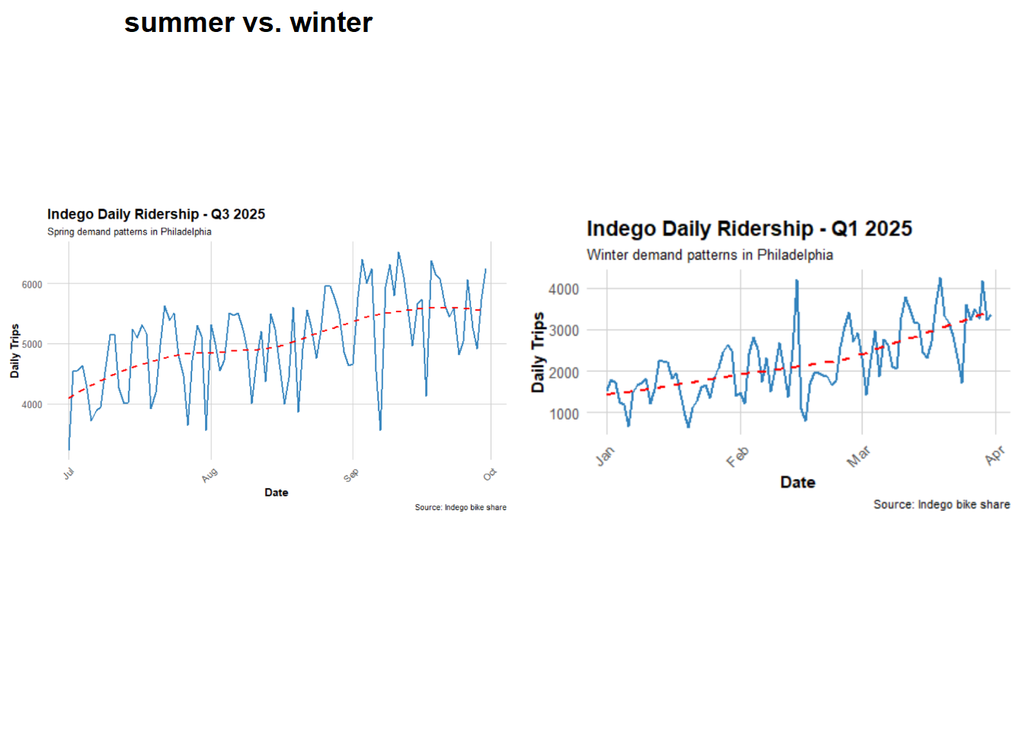

```r
## Comparison between Q1 2025 and Q3 2024 (summer vs. winter)
library(ggplot2)
library(png)
library(grid)
library(cowplot)

img1 <- png::readPNG("data/daily_ridership_Q3.png")
p_left <- grid::rasterGrob(img1, interpolate = TRUE)

img2 <- png::readPNG("data/daily_ridership_Q1.png")
p_right <- grid::rasterGrob(img2, interpolate = TRUE)

cowplot::plot_grid(
  p_left,
  p_right,
  labels = c("summer vs. winter"),
  ncol = 2
)
```

## Important Features

```r
# Use partial R square to determine the  most important feature
library(rsq)
rsq.partial(model2)
```

```
$adjustment
[1] FALSE

$variable
[1] "as.factor(hour)" "dotw_simple"     "Temperature"     "Precipitation"
[5] "lag1Hour"        "lag3Hours"       "lag1day"

$partial.rsq
[1] 0.04559664069 0.00048407188 0.00025104419 0.00002248911 0.15930182252
[6] 0.01891740820 0.02596483603
```

# SPACE-TIME ERROR ANALYSIS

## Observed vs. Predicted

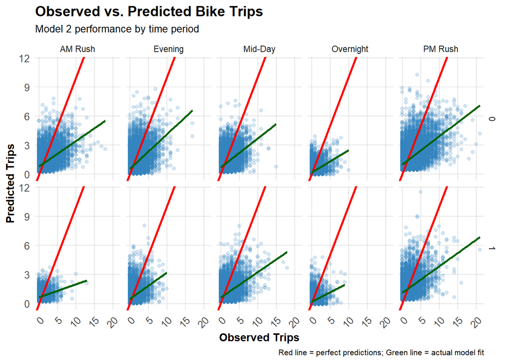

```r
test <- test %>%
  mutate(
    error = Trip_Count - pred2,            #best result model (change if ness)
    abs_error = abs(error),
    time_of_day = case_when(
      hour < 7 ~ "Overnight",
      hour >= 7 & hour < 10 ~ "AM Rush",
      hour >= 10 & hour < 15 ~ "Mid-Day",
      hour >= 15 & hour <= 18 ~ "PM Rush",
      hour > 18 ~ "Evening"
    )
  )

# Scatter plot by time and day type
ggplot(test, aes(x = Trip_Count, y = pred2)) +
  geom_point(alpha = 0.2, color = "#3182bd") +
  geom_abline(slope = 1, intercept = 0, color = "red", linewidth = 1) +
  geom_smooth(method = "lm", se = FALSE, color = "darkgreen") +
  facet_grid(weekend ~ time_of_day) +
  labs(
    title = "Observed vs. Predicted Bike Trips",
    subtitle = "Model 2 performance by time period",
    x = "Observed Trips",
    y = "Predicted Trips",
    caption = "Red line = perfect predictions; Green line = actual model fit"
  ) +
  plotTheme
```

## Spatial Error Patterns

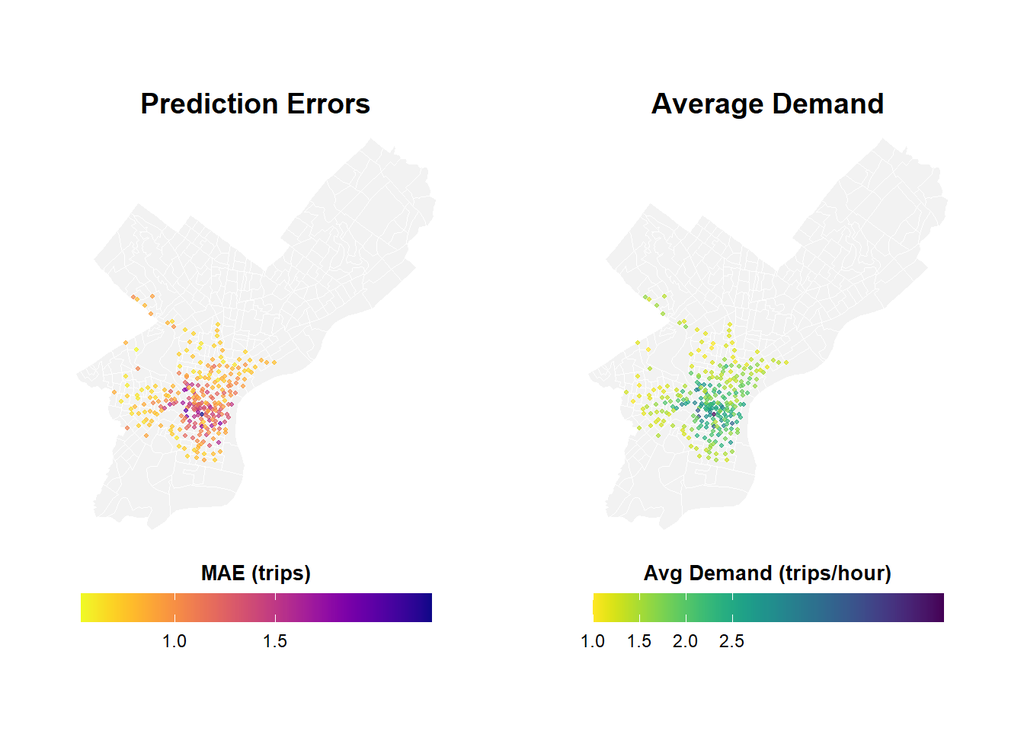

```r
# Calculate MAE by station
station_errors <- test %>%
  group_by(start_station, start_lat.x, start_lon.y) %>%
  summarize(
    MAE = mean(abs_error, na.rm = TRUE),
    avg_demand = mean(Trip_Count, na.rm = TRUE),
    .groups = "drop"
  ) %>%
  filter(!is.na(start_lat.x), !is.na(start_lon.y))

## Create Two Maps Side-by-Side with Proper Legends (sorry these maps are ugly)

# Calculate station errors
station_errors <- test %>%
  filter(!is.na(pred2)) %>%
  group_by(start_station, start_lat.x, start_lon.y) %>%
  summarize(
    MAE = mean(abs(Trip_Count - pred2), na.rm = TRUE),
    avg_demand = mean(Trip_Count, na.rm = TRUE),
    .groups = "drop"
  ) %>%
  filter(!is.na(start_lat.x), !is.na(start_lon.y))

# Map 1: Prediction Errors
p1 <- ggplot() +
  geom_sf(data = philly_census, fill = "grey95", color = "white", size = 0.1) +
  geom_point(
    data = station_errors,
    aes(x = start_lon.y, y = start_lat.x, color = MAE),
    size = 0.8,
    alpha = 0.7
  ) +
  scale_color_viridis(
    option = "plasma",
    name = "MAE (trips)",
    direction = -1,
    breaks = c(0.5, 1.0, 1.5),
    labels = c("0.5", "1.0", "1.5")
  ) +
  labs(title = "Prediction Errors") +
  mapTheme +
  theme(
    legend.position = "bottom",
    legend.title = element_text(size = 10, face = "bold"),
    legend.text = element_text(size = 9),
    plot.title = element_text(size = 14, face = "bold", hjust = 0.5)
  ) +
  guides(color = guide_colorbar(
    barwidth = 12,
    barheight = 1,
    title.position = "top",
    title.hjust = 0.5
  ))

# Map 2: Average Demand
p2 <- ggplot() +
  geom_sf(data = philly_census, fill = "grey95", color = "white", size = 0.1) +
  geom_point(
    data = station_errors,
    aes(x = start_lon.y, y = start_lat.x, color = avg_demand),
    size = 0.8,
    alpha = 0.7
  ) +
  scale_color_viridis(
    option = "viridis",
    name = "Avg Demand (trips/hour)",
    direction = -1,
    breaks = c(0.5, 1.0, 1.5, 2.0, 2.5),
    labels = c("0.5", "1.0", "1.5", "2.0", "2.5")
  ) +
  labs(title = "Average Demand") +
  mapTheme +
  theme(
    legend.position = "bottom",
    legend.title = element_text(size = 10, face = "bold"),
    legend.text = element_text(size = 9),
    plot.title = element_text(size = 14, face = "bold", hjust = 0.5)
  ) +
  guides(color = guide_colorbar(
    barwidth = 12,
    barheight = 1,
    title.position = "top",
    title.hjust = 0.5
  ))

library(gridExtra)

# Combine
grid.arrange(
  p1, p2,
  ncol = 2
  )
```

## Temporal Error Patterns

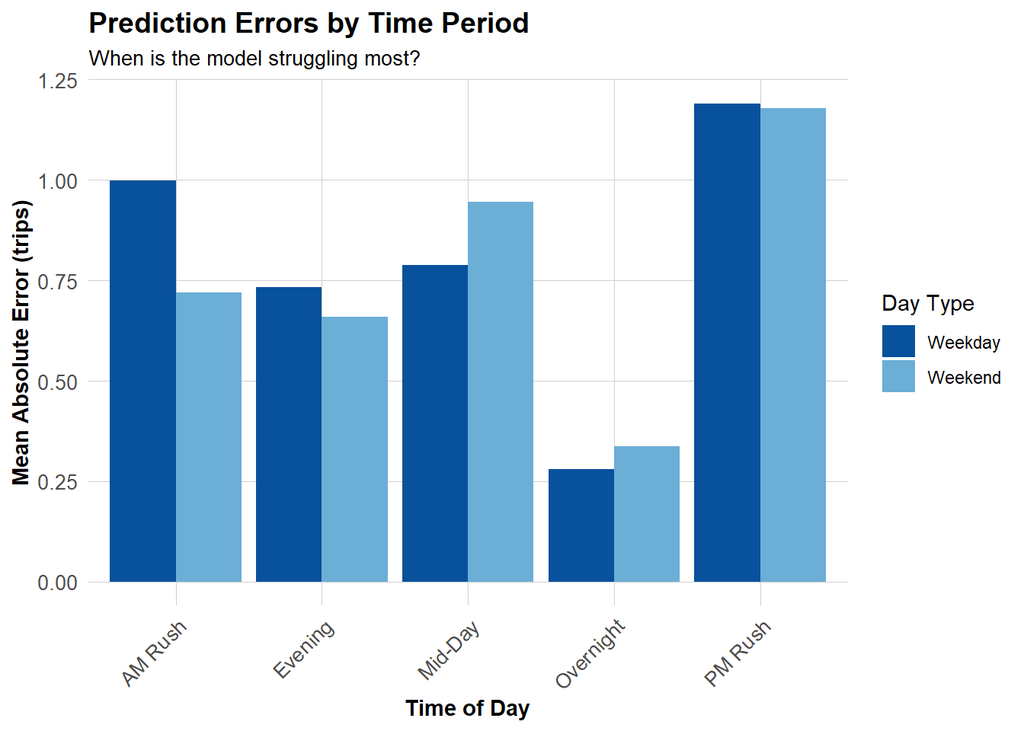

```r
# MAE by time of day and day type
temporal_errors <- test %>%
  group_by(time_of_day, weekend) %>%
  summarize(
    MAE = mean(abs_error, na.rm = TRUE),
    .groups = "drop"
  ) %>%
  mutate(day_type = ifelse(weekend == 1, "Weekend", "Weekday"))

ggplot(temporal_errors, aes(x = time_of_day, y = MAE, fill = day_type)) +
  geom_col(position = "dodge") +
  scale_fill_manual(values = c("Weekday" = "#08519c", "Weekend" = "#6baed6")) +
  labs(
    title = "Prediction Errors by Time Period",
    subtitle = "When is the model struggling most?",
    x = "Time of Day",
    y = "Mean Absolute Error (trips)",
    fill = "Day Type"
  ) +
  plotTheme +
  theme(axis.text.x = element_text(angle = 45, hjust = 1))
```

## Errors and Demographics

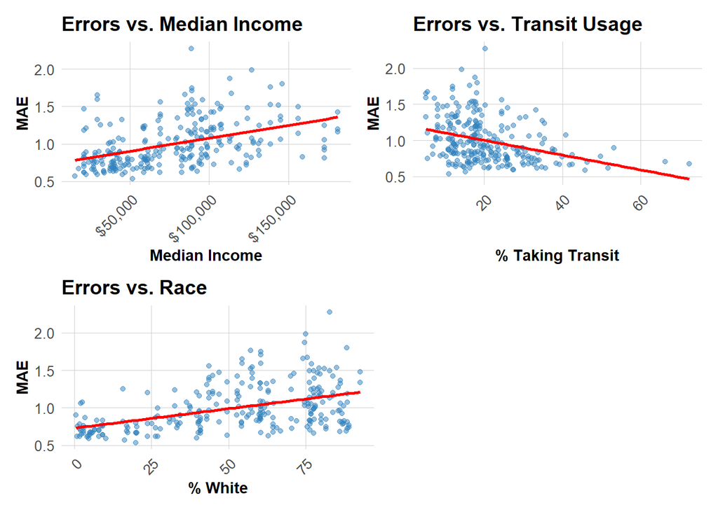

```r
# Join demographic data to station errors
station_errors_demo <- station_errors %>%
  left_join(
    station_attributes %>% select(start_station, Med_Inc, Percent_Taking_Transit, Percent_White),
    by = "start_station"
  ) %>%
  filter(!is.na(Med_Inc))

# Create plots
p1 <- ggplot(station_errors_demo, aes(x = Med_Inc, y = MAE)) +
  geom_point(alpha = 0.5, color = "#3182bd") +
  geom_smooth(method = "lm", se = FALSE, color = "red") +
  scale_x_continuous(labels = scales::dollar) +
  labs(title = "Errors vs. Median Income", x = "Median Income", y = "MAE") +
  plotTheme

p2 <- ggplot(station_errors_demo, aes(x = Percent_Taking_Transit, y = MAE)) +
  geom_point(alpha = 0.5, color = "#3182bd") +
  geom_smooth(method = "lm", se = FALSE, color = "red") +
  labs(title = "Errors vs. Transit Usage", x = "% Taking Transit", y = "MAE") +
  plotTheme

p3 <- ggplot(station_errors_demo, aes(x = Percent_White, y = MAE)) +
  geom_point(alpha = 0.5, color = "#3182bd") +
  geom_smooth(method = "lm", se = FALSE, color = "red") +
  labs(title = "Errors vs. Race", x = "% White", y = "MAE") +
  plotTheme

(p1 | p2) / (p3 | plot_spacer())
```

Errors tend to be slightly higher in higher-income and higher-percent-White neighborhoods, while they are lower in areas with high transit usage. This suggests the model struggles more in wealthier, less transit-oriented areas. The equity implication is that model performance is not uniform—some communities may receive less accurate predictions than others, which could affect planning decisions if not addressed.

# Feature Engineering

## Spatial features

```r
library(geosphere)

## Distance to Center City

# Center City coordinate (Use Philadelphia City Hall)
center_lat <- 39.952800
center_lon <- -75.163500

# Calculate distance in kilometers
study_panel_complete <- study_panel_complete %>%
  mutate(
    dist_to_center = distHaversine(
      cbind(start_lon.y, start_lat.y),
      cbind(center_lon, center_lat)
    ) / 1000  # convert meters to km
  )
```

## Trip history features

```r
## Rolling 7-day average demand
library(slider)

study_panel_complete <- study_panel_complete %>%
  arrange(start_station, date, hour) %>%
  group_by(start_station) %>%
  mutate(
    rolling7 = slide_dbl(
      Trip_Count,
      mean,
      .before = 168,
      .complete = TRUE
    )
  ) %>%
  ungroup()
```

## Split train/test Dataset

```r
# Which stations have trips in BOTH early and late periods?
early_stations <- study_panel_complete %>%
  filter(week < 36) %>%
  filter(Trip_Count > 0) %>%
  distinct(start_station) %>%
  pull(start_station)

late_stations <- study_panel_complete %>%
  filter(week >= 36) %>%
  filter(Trip_Count > 0) %>%
  distinct(start_station) %>%
  pull(start_station)

# Keep only stations that appear in BOTH periods
common_stations <- intersect(early_stations, late_stations)


# Filter panel to only common stations
study_panel_complete <- study_panel_complete %>%
  filter(start_station %in% common_stations)

# NOW create train/test split
train <- study_panel_complete %>%
  filter(week < 36)

test <- study_panel_complete %>%
  filter(week >= 36)

cat("Training observations:", format(nrow(train), big.mark = ","), "\n")
```

```
Training observations: 501,541
```

```r
cat("Testing observations:", format(nrow(test), big.mark = ","), "\n")
```

```
Testing observations: 207,244
```

```r
cat("Training date range:", min(train$date), "to", max(train$date), "\n")
```

```
Training date range: 20270 to 20333
```

```r
cat("Testing date range:", min(test$date), "to", max(test$date), "\n")
```

```
Testing date range: 20334 to 20361
```

## Add two new presictors into the best model

```r
# Create day of week factor with treatment (dummy) coding
train <- train %>%
  mutate(dotw_simple = factor(dotw, levels = c("Mon", "Tue", "Wed", "Thu", "Fri", "Sat", "Sun")))

# Set contrasts to treatment coding (dummy variables)
contrasts(train$dotw_simple) <- contr.treatment(7)

model_n <- lm(
  Trip_Count ~ as.factor(hour) + dotw_simple + Temperature + Precipitation +
    lag1Hour + lag3Hours + lag1day + dist_to_center + rolling7,
  data = train
)

summary(model_n)
```

```
Call:
lm(formula = Trip_Count ~ as.factor(hour) + dotw_simple + Temperature +
    Precipitation + lag1Hour + lag3Hours + lag1day + dist_to_center +
    rolling7, data = train)

Residuals:
    Min      1Q  Median      3Q     Max
-6.9299 -0.5079 -0.1184  0.2803 17.6736

Coefficients:
                    Estimate Std. Error t value             Pr(>|t|)
(Intercept)       -0.2646910  0.0233566 -11.333 < 0.0000000000000002 ***
as.factor(hour)1  -0.0215583  0.0105788  -2.038             0.041562 *
as.factor(hour)2  -0.0468092  0.0106622  -4.390  0.00001132766890489 ***
as.factor(hour)3  -0.0666273  0.0106586  -6.251  0.00000000040806655 ***
as.factor(hour)4  -0.0353589  0.0104881  -3.371             0.000748 ***
as.factor(hour)5   0.0673682  0.0107866   6.246  0.00000000042271421 ***
as.factor(hour)6   0.2587318  0.0105329  24.564 < 0.0000000000000002 ***
as.factor(hour)7   0.4356190  0.0105591  41.255 < 0.0000000000000002 ***
as.factor(hour)8   0.7787979  0.0105195  74.034 < 0.0000000000000002 ***
as.factor(hour)9   0.3600817  0.0106951  33.668 < 0.0000000000000002 ***
as.factor(hour)10  0.2885503  0.0105564  27.334 < 0.0000000000000002 ***
as.factor(hour)11  0.3687875  0.0102336  36.037 < 0.0000000000000002 ***
as.factor(hour)12  0.4246509  0.0104091  40.796 < 0.0000000000000002 ***
as.factor(hour)13  0.4644507  0.0105663  43.956 < 0.0000000000000002 ***
as.factor(hour)14  0.5169114  0.0104380  49.522 < 0.0000000000000002 ***
as.factor(hour)15  0.5954390  0.0105133  56.637 < 0.0000000000000002 ***
as.factor(hour)16  0.7673669  0.0106708  71.913 < 0.0000000000000002 ***
as.factor(hour)17  1.0273652  0.0108907  94.334 < 0.0000000000000002 ***
as.factor(hour)18  0.6105871  0.0108756  56.143 < 0.0000000000000002 ***
as.factor(hour)19  0.4767052  0.0109722  43.447 < 0.0000000000000002 ***
as.factor(hour)20  0.2813512  0.0108853  25.847 < 0.0000000000000002 ***
as.factor(hour)21  0.2174694  0.0105602  20.593 < 0.0000000000000002 ***
as.factor(hour)22  0.1605793  0.0104308  15.395 < 0.0000000000000002 ***
as.factor(hour)23  0.0739143  0.0104373   7.082  0.00000000000142521 ***
dotw_simple2       0.0575659  0.0055434  10.385 < 0.0000000000000002 ***
dotw_simple3       0.0161450  0.0055902   2.888             0.003876 **
dotw_simple4       0.0360255  0.0055350   6.509  0.00000000007587620 ***
dotw_simple5       0.0463412  0.0058387   7.937  0.00000000000000208 ***
dotw_simple6      -0.0197771  0.0058929  -3.356             0.000791 ***
dotw_simple7      -0.0614182  0.0055898 -10.988 < 0.0000000000000002 ***
Temperature       -0.0006399  0.0002692  -2.377             0.017439 *
Precipitation     -0.0857631  0.0225474  -3.804             0.000143 ***
lag1Hour           0.3346474  0.0014081 237.659 < 0.0000000000000002 ***
lag3Hours          0.0536807  0.0013994  38.361 < 0.0000000000000002 ***
lag1day            0.0682287  0.0013108  52.051 < 0.0000000000000002 ***
dist_to_center    -0.0042454  0.0010508  -4.040  0.00005344060129632 ***
rolling7           0.5257068  0.0041081 127.969 < 0.0000000000000002 ***
---
Signif. codes:  0 '***' 0.001 '**' 0.01 '*' 0.05 '.' 0.1 ' ' 1

Residual standard error: 1.029 on 457320 degrees of freedom
  (44184 observations deleted due to missingness)
Multiple R-squared:  0.3849,    Adjusted R-squared:  0.3849
F-statistic:  7951 on 36 and 457320 DF,  p-value: < 0.00000000000000022
```

## New Model Evaluation and MAE

```r
# Get predictions on test set

# Create day of week factor with treatment (dummy) coding
test <- test %>%
  mutate(dotw_simple = factor(dotw, levels = c("Mon", "Tue", "Wed", "Thu", "Fri", "Sat", "Sun")))

# Set contrasts to treatment coding (dummy variables)
contrasts(test$dotw_simple) <- contr.treatment(7)

test <- test %>%
  mutate(
    pred_n = predict(model_n, newdata = test)
  )

# Calculate MAE for each model
mae_results_new <- data.frame(
  Model = c(
    "2. + Temporal Lags",
    "New Model. + Rolling 7-day average demand and Distance to Center City",
    "New Poisson Model"
  ),
  MAE = c(
    mean(abs(test$Trip_Count - test$pred2), na.rm = TRUE),
    mean(abs(test$Trip_Count - test$pred_n), na.rm = TRUE),
    mean(abs(test$Trip_Count - test$pred_pois), na.rm = TRUE)
  ),
   RMSE = c(
    sqrt(mean((test$Trip_Count - test$pred2)^2,  na.rm = TRUE)),
    sqrt(mean((test$Trip_Count - test$pred_n)^2, na.rm = TRUE)),
    sqrt(mean((test$Trip_Count - test$pred_pois)^2, na.rm = TRUE))
  )
)

kable(mae_results_new,
      digits = 5,
      caption = "Mean Absolute Error by Model (Test Set)",
      col.names = c("Model", "MAE (trips)", "RMSE (trips)")) %>%
  kable_styling(bootstrap_options = c("striped", "hover"))
```

Mean Absolute Error by Model (Test Set)

| Model | MAE (trips) | RMSE (trips) |
| --- | --- | --- |
| 2. + Temporal Lags | NaN | NaN |
| New Model. + Rolling 7-day average demand and Distance to Center City | 0.71904 | 1.12527 |
| New Poisson Model | NaN | NaN |

## Poisson model

```r
## Train a poisson model
model_poisson <- glm(
  Trip_Count ~ as.factor(hour) + dotw_simple + Temperature + Precipitation +
    lag1Hour + lag3Hours + lag1day + dist_to_center + rolling7,
  family = poisson(link = "log"),
  data   = train
)

summary(model_poisson)
```

```
Call:
glm(formula = Trip_Count ~ as.factor(hour) + dotw_simple + Temperature +
    Precipitation + lag1Hour + lag3Hours + lag1day + dist_to_center +
    rolling7, family = poisson(link = "log"), data = train)

Coefficients:
                      Estimate   Std. Error  z value             Pr(>|z|)
(Intercept)       -1.597467267  0.028671578  -55.716 < 0.0000000000000002 ***
as.factor(hour)1  -0.297839161  0.023656495  -12.590 < 0.0000000000000002 ***
as.factor(hour)2  -0.703090169  0.027176906  -25.871 < 0.0000000000000002 ***
as.factor(hour)3  -1.282650758  0.033924069  -37.809 < 0.0000000000000002 ***
as.factor(hour)4  -1.077887323  0.030691237  -35.120 < 0.0000000000000002 ***
as.factor(hour)5  -0.127736134  0.023033554   -5.546         0.0000000293 ***
as.factor(hour)6   0.670210064  0.018691904   35.856 < 0.0000000000000002 ***
as.factor(hour)7   1.105948527  0.017382196   63.625 < 0.0000000000000002 ***
as.factor(hour)8   1.537352832  0.016474887   93.315 < 0.0000000000000002 ***
as.factor(hour)9   1.153985656  0.017059476   67.645 < 0.0000000000000002 ***
as.factor(hour)10  1.033953542  0.017297023   59.776 < 0.0000000000000002 ***
as.factor(hour)11  1.116417738  0.016942989   65.893 < 0.0000000000000002 ***
as.factor(hour)12  1.193333179  0.016894954   70.633 < 0.0000000000000002 ***
as.factor(hour)13  1.243489696  0.016875262   73.687 < 0.0000000000000002 ***
as.factor(hour)14  1.302069360  0.016687381   78.027 < 0.0000000000000002 ***
as.factor(hour)15  1.388750233  0.016583110   83.745 < 0.0000000000000002 ***
as.factor(hour)16  1.527543423  0.016440056   92.916 < 0.0000000000000002 ***
as.factor(hour)17  1.674794784  0.016313994  102.660 < 0.0000000000000002 ***
as.factor(hour)18  1.370316653  0.016669500   82.205 < 0.0000000000000002 ***
as.factor(hour)19  1.279863318  0.016901594   75.724 < 0.0000000000000002 ***
as.factor(hour)20  1.048668843  0.017370716   60.370 < 0.0000000000000002 ***
as.factor(hour)21  0.896386343  0.017567283   51.026 < 0.0000000000000002 ***
as.factor(hour)22  0.725936816  0.018094248   40.120 < 0.0000000000000002 ***
as.factor(hour)23  0.397661117  0.019247374   20.661 < 0.0000000000000002 ***
dotw_simple2       0.088399022  0.006398730   13.815 < 0.0000000000000002 ***
dotw_simple3       0.017801061  0.006537671    2.723              0.00647 **
dotw_simple4       0.056206234  0.006486085    8.666 < 0.0000000000000002 ***
dotw_simple5       0.098473411  0.006721049   14.651 < 0.0000000000000002 ***
dotw_simple6       0.000001129  0.006924753    0.000              0.99987
dotw_simple7      -0.089631398  0.006807574  -13.166 < 0.0000000000000002 ***
Temperature       -0.000549945  0.000296382   -1.856              0.06352 .
Precipitation     -1.000017321  0.055777627  -17.929 < 0.0000000000000002 ***
lag1Hour           0.129445057  0.000896418  144.403 < 0.0000000000000002 ***
lag3Hours          0.017797063  0.001083996   16.418 < 0.0000000000000002 ***
lag1day            0.020071443  0.000987413   20.327 < 0.0000000000000002 ***
dist_to_center    -0.169607202  0.001522073 -111.432 < 0.0000000000000002 ***
rolling7           0.540747606  0.003586507  150.773 < 0.0000000000000002 ***
---
Signif. codes:  0 '***' 0.001 '**' 0.01 '*' 0.05 '.' 0.1 ' ' 1

(Dispersion parameter for poisson family taken to be 1)

    Null deviance: 810357  on 457356  degrees of freedom
Residual deviance: 478516  on 457320  degrees of freedom
  (44184 observations deleted due to missingness)
AIC: 876846

Number of Fisher Scoring iterations: 6
```

```r
# Calculate dispersion parameter
dispersion <- sum(residuals(model_poisson, type = "pearson")^2) /
              model_poisson$df.residual

cat("Dispersion parameter:", round(dispersion, 2), "\n")
```

```
Dispersion parameter: 1.31
```

```r
cat("Rule of thumb: >1.5 suggests overdispersion\n")
```

```
Rule of thumb: >1.5 suggests overdispersion
```

```r
if (dispersion > 1.5) {
  cat("⚠ Overdispersion detected! Consider Negative Binomial model.\n")
} else {
  cat("✓ Dispersion looks okay for Poisson model.\n")
}
```

```
✓ Dispersion looks okay for Poisson model.
```